# Tutorium 3

Gruppen 2 und 4  
Samuel Teuber  
propa@teuber.dev  
https://teuber.dev/propa

# Übungsblätter

- **Fragen? Probleme?** (Praktomat?)

**UMFRAGE**

# Vorbemerkung 0

Haskell ist **anders**, aber **lasst euch davon nicht verwirren!**

1. Problem lesen
2. Algorithmus überlegen/nachschauen
3. Evtl. Pseudocode
4. Wie implementiere ich **diesen Mechanismus** in Haskell?

**Mergesort:** Nutzt die Algorithmen, die angegeben sind!

# Vorbemerkung 1

```
f (x:xs) a
    | a = [x]
    | otherwise = x:xs
```

Wie kann man das schöner schreiben?

Zwei Optimierungsmöglichkeiten:

```
f (x:xs) True = [x]
f l False = l
```

...oder...

```
f l@(x:xs) a
    | a = [x]
    | otherwise = l
```

```haskell
f l@(x:xs) a
    | a = [x]
    | otherwise = l
f [1,2,3] True
f [1,2,3] False
```

```
[1]
```

```
[1,2,3]
```

# Vorbemerkung 2

```haskell
f x
  | even x = x `div` 2
  | odd x = (x-1) `div` 2

f' x = x `div` 2
```

```haskell
f 5
f' 5
```

```
2
```

```
2
```

# Aufgabe 1: Polynome

```
type Polynom = [Double]
```

- Polynom Multiplikation mit Konstante

  ```
  cmult :: Polynom -> Double -> Polynom
  cmult p c = map (*c) p
  ```

- Polynom Auswertung mit dem Horner Schema
  $$ a_0 + x * (a_1 + x * (a_2 + \dots (a_{n-1} + x * a_n) \dots) ) $$

  ```
  eval :: Polynom -> Double -> Double
  eval p x = foldr (\a v -> a + v*x) 0 p
  ```

- Ableitung

  ```
  deriv :: Polynom -> Polynom
  deriv [] = []
  deriv p  =zipWith (*) [1..] (tail p)
  ```

# Aufgabe 2: Collatz

- Unendliche Liste der Folgenmitglieder für Startwert `a0`

  ```
  collatz :: Int -> [Int]
  collatz m = iterate next m
    where
            next :: Int -> Int
            next an
                | an `mod` 2 == 0 = an `div` 2
                | otherwise = 3 * an + 1
  ```

- Zählen bis zur ersten 1

  ```
  num m = length (takeWhile (/= 1) (collatz m)))
  ```

- Suche nach maximalem `num` in Interval

  ```
  maxNum a b = foldl maxPair (0,0) (map (\m -> (m, num m)) [a..b])
    where maxPair (m,n) (m',n') = if n > n' then (m,n) else (m',n')
  ```

# Aufgabe 3: Prime Powers

**Klausuraufgabe**

- Merge auf unendlichen Listen

  ```
  merge [] b = b
  merge a [] = a
  merge l1@(x:xs) l2@(y:ys)
    | (x<y) = x:merge xs l2
    | otherwise = y:merge l1 ys
  ```

- Erste $n$ Potenzen aller Primzahlen

  ```
  primepowers n = foldr merge [] [map (^i) primes | i <- [1..n]]
  ```

# B-Seite: Termsprachen

**Umfrage**

# Noch ein Wort zur Frage von letzter Woche...

Typ [I]: (a -> a) -> (a -> a)  
Typ [II]: a -> a

> Wenn eine Funktion Typ [II] hat, "dann hat sie eigentlich auch Typ [I]"

> Wenn eine Funktion Typ [II] hat, dann kann man sie verwenden als hätte sie Typ [I]

# Typen

...schon wieder...

- Jeder Ausdruck in Haskell hat einen Typ
- Haskell ist damit statisch typisiert
- Jeder Ausdruck wertet zu Werten des jeweiligen Typs aus
- Typen werden **automatisch inferiert**

# Polymorphe Typen

...schon wieder...

**Beispiel:** Listen-Typ

- `[t]` ist der Typ von Listen mit Elementen vom Typ `t`
- *Typvariable* `t` beliebig

**Sichtweisen:**

- Typvariablen parametrisieren polymorphe Typen
- Typkonstruktoren wie `[ ]` erzeugen neue Typen aus bestehenden

**Vergleichbares in Java:** Generics

```
LinkedList<T>
```

## Funktionstypen

... sind polymorph, denn...

```
s -> t
```

... beschreibt den Typ aller Funktionen von `s` nach `t` (`s`,`t` beliebig)

# Tupel

...sind polymorph, denn...

```
(,) :: s -> t -> (s,t)
```

...und umgekehrt...

```
fst :: (s,t) -> s
snd :: (s,t) -> t
```

# Typsynonyme

Verbessert die Lesbarkeit:

```
type Polynom = [Double]
```

# Explizite Typisierung

...kennen wir auch schon...

```
foldr :: (a -> b -> b) -> b -> [a] -> b
```

- Übersichtlichkeit
- Hilft beim Debugging

# Wollen wir statt Klassen einfach Tupel benutzen?

```
type Name = (String, String)
type MNumber = Integer -- Für die Addition von Matrikelnummern...
type Address = (String, Integer, String) -- Straße, PLZ und Ort
type Grades = [(String, Double)] -- Fach Name und Note
type Student = (Name,MNumber, Address, Grades)
```

**Ist das eine gute Idee?**

# NEIN

- Tupel könnte für beliebige Werte benutzt werden
- Kaum/Keine explizite Bedeutung

# Algebraische Datentypen

Definition neuer Typen durch Auflistung aller *Konstruktoren*:

```
data Address = Address String Integer String
data UniversityPerson = Student String Integer Address
                        | Professor String Address
```

Ergibt die folgenden Konstruktoren:

```
Address :: String -> Integer -> String -> Address
Student :: String -> Integer -> Adress -> UniversityPerson
Professor :: String -> Adress -> UniversityPerson
```

Jede*r `Student` und jede*r `Professor` ist eine `UniversityPerson`

# Pattern-Matching

```haskell
data UniversityPerson = Student String Integer
                        | Professor String
getName :: UniversityPerson -> String
getName (Student name _) = name
getName (Professor name)  = name

getName (Student "Samuel" 424242)
getName (Professor "Prof. Dr. Snelting")
```

```
"Samuel"
```

```
"Prof. Dr. Snelting"
```

# Polymorphe Algebraische Datentypen

z.B. Realisierung von **optionalen Werten**:

```
data Maybe t = Nothing | Just t
Just True :: Maybe Bool
```

# Polymorphe Algebraische Datentypen (2)

```haskell
data Either t s = Option1 t | Option2 s
```

```haskell
-- Übungsaufgabe 1 (2min)
process :: (t -> a) -> (s -> a) -> Either t s -> a
process f _ (Option1 a) = f a
process _ g (Option2 b) = g b
```

```haskell
printBool :: Bool -> String
printBool False = "Aww, it's false"
printBool True = "Yay, it's true"

printInt :: Int -> String
printInt x
    | x<=0 = "Nope, not gonna spread this negativity"
    | (x>0) && (x<100) = "This number is pretty small"
    | otherwise = "Woah that's a big number"

print' = process printBool printInt

:t print'
print' (Option1 False)
print' (Option2 (-101))
```

print' :: Either Bool Int -> String

```
"Aww, it's false"
```

```
"Nope, not gonna spread this negativity"
```

# Polymorphe Rekursive Algebraische Datentypen

```
data Tree t = Leaf t | Node (Tree t) t (Tree t)
```

```haskell
-- Übungsaufgabe 2:
-- Definiere einen polymorphen Datentyp für einfach verkettete Listen
-- Definiere eine Operation zur Berechnung der Listenlänge
data List a = End | Part a (List a)

listLength :: List a -> Int
listLength End = 0
listLength (Part a l) = 1 + (listLength l)

listLength (Part 2 End)
```

Redundant bracket

Found:

1 + (listLength l)

Why Not:

1 + listLength l

```
1
```

# Typklassen

...endlich...

- Zusammenfassen von Typen anhand von definierter Operationen
- Java: ~Interfaces **Beispiel `Eq`**:

  ```
  class Eq t where
    (==) :: t -> t -> Bool
    (/=) :: t -> t -> Bool
  ```

  **Default Implementierungen**:

  ```
  x /= y = not (x == y)
    x == y = not (x /= y)
  ```

# Typklassen implementieren

```
instance Eq Bool where
    True == True = True
    False == False = True
    x == y = False
```

**Auch für Polymorphe Typen**:

```haskell
data Maybe t = Nothing | Just t

class Defaultable t where
    getDefault :: t a -> a -> a

instance Defaultable Maybe where
    getDefault (Just x) c = x
    getDefault Nothing c = c

getDefault Nothing 1
getDefault (Just 10) 1
```

```
1
```

```
10
```

# Typklassen Vererbung

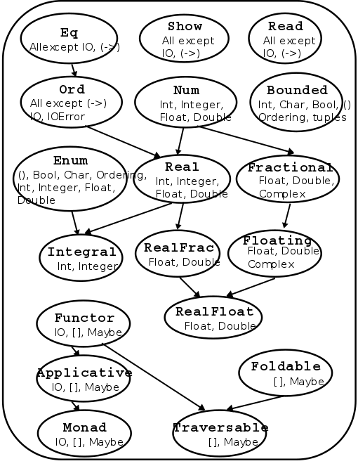

```haskell
:t foldr
```

foldr :: forall (t :: * -> *) a b. Foldable t => (a -> b -> b) -> b -> t a -> b

# Automatische Instanziierung

...für algebraische Datenstrukturen  
Basierend auf innenliegenden Typen:

```haskell
data Shape = Circle Double | Rectancle Double Double deriving Eq
```

# Übungsaufgabe

Befindet sich ein Element in einem Baum?

```haskell
-- Übungsaufgabe 3
data Tree t = Leaf t | Node (Tree t) t (Tree t)

treeFind :: (Eq a) => Tree a -> a -> Bool
treeFind (Leaf x) y = x == y
treeFind (Node x y z) a = treeFind x a || y==a || treeFind z a
```

```haskell
myTree = Node (Node (Leaf "test") "foo" (Leaf "tset")) "abc" (Node (Leaf "42") "bar" (Leaf "24") )
treeFind myTree "test"
treeFind myTree "thisisnotinmytree"
```

```
True
```

```
False
```

# Übungsaufabe

`map` aber für Bäume

```haskell
-- Übungsaufgabe 4
data Tree t = Leaf t | Node (Tree t) t (Tree t) deriving Show

treeMap :: (a->b) -> Tree a -> Tree b
treeMap f (Leaf x) = Leaf (f x)
treeMap f (Node l x r) = Node (treeMap f l) (f x) (treeMap f r)
```

```haskell
myTree = Node (Node (Leaf "test") "foo" (Leaf "tset")) "abc" (Node (Leaf "42") "bar" (Leaf "24") )
treeMap tail myTree
```

```
Node (Node (Leaf "est") "oo" (Leaf "set")) "bc" (Node (Leaf "2") "ar" (Leaf "4"))
```

# Übungsaufgabe

Typklasse für Datenstrukturen die `Mappable` sind.

Wir wollen:

- Typklasse die uns die Funktion `dMap` auf algebraischen Datentypen mit einem Parameter erlaubt

  ```
  class Mappable -- ...
  ```

- Eine Implementierung dieser Typklasse für `Tree`

  ```
  instance Mappable Tree -- ...
  ```

```haskell
-- Übungsaufgabe 5
class Mappable t where
    dMap :: (a->b) -> t a -> t b

instance Mappable Tree where
    dMap f t = treeMap f t
```

Eta reduce

Found:

dMap f t = treeMap f t

Why Not:

dMap = treeMap